# 2. Define the Network Architecture

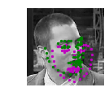

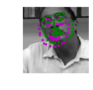

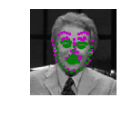

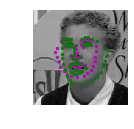

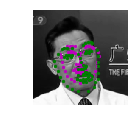

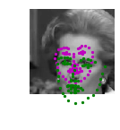

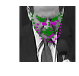

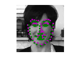

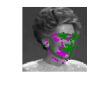

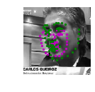

```python
# 2  model 2
# 5 epochs
#criterion = nn.MSELoss()
# optimizer = optim.Adam(params = net.parameters(), lr=0.001)

visualize_output(test_images, test_outputs, gt_pts)
```

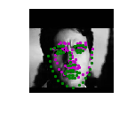

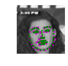

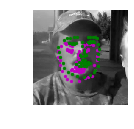

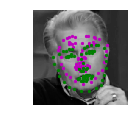

[figure not shown]

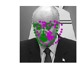

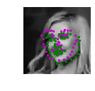

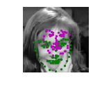

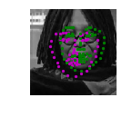

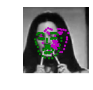

```python
# 1  model 2
# 2 epochs
#criterion = nn.MSELoss()
# optimizer = optim.Adam(params = net.parameters(), lr=0.001)

visualize_output(test_images, test_outputs, gt_pts)
```

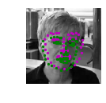

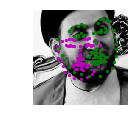

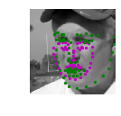

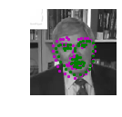

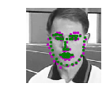

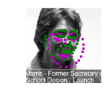

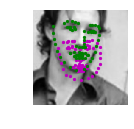

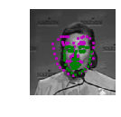

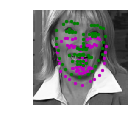

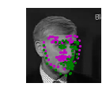

```python
## TODO: visualize your test output
# you can use the same function as before, by un-commenting the line below:


# 1 model b4
#criterion = nn.MSELoss()
# optimizer = optim.Adam(params = net.parameters(), lr=0.001)

visualize_output(test_images, test_outputs, gt_pts)
```

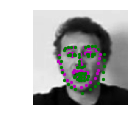

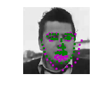

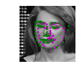

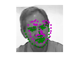

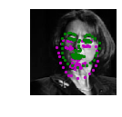

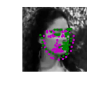

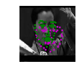

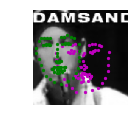

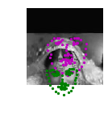

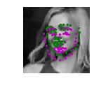

```python
# 2  model b4
#criterion = nn.MSELoss()
#optimizer = optim.Adam(params = net.parameters(), lr=0.001,amsgrad=True)
visualize_output(test_images, test_outputs, gt_pts)
```

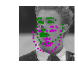

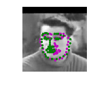

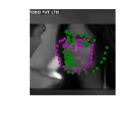

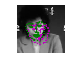

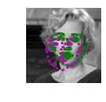

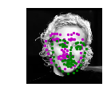

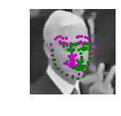

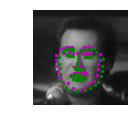

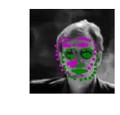

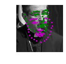

```python
#5 model b4
#criterion = nn.SmoothL1Loss()
# optimizer = optim.Adam(params = net.parameters(), lr=0.001)
visualize_output(test_images, test_outputs, gt_pts)
```

Once you've found a good model (or two), save your model so you can load it and use it later!

```python
## TODO: change the name to something uniqe for each new model
model_dir = 'saved_models/'
model_name = 'keypoints_model_1.pt'

# after training, save your model parameters in the dir 'saved_models'
torch.save(net.state_dict(), model_dir+model_name)
```

```python
# Loading the model
net.load_state_dict(torch.load('./saved_models/keypoints_model_1.pt'))
net.eval()
```

```
Net(
  (conv1): Conv2d(1, 32, kernel_size=(5, 5), stride=(1, 1))
  (conv2): Conv2d(32, 64, kernel_size=(3, 3), stride=(1, 1))
  (conv3): Conv2d(64, 128, kernel_size=(3, 3), stride=(1, 1))
  (conv4): Conv2d(128, 256, kernel_size=(2, 2), stride=(1, 1))
  (pool): MaxPool2d(kernel_size=2, stride=2, padding=0, dilation=1, ceil_mode=False)
  (fc1): Linear(in_features=36864, out_features=1000, bias=True)
  (fc2): Linear(in_features=1000, out_features=500, bias=True)
  (fc3): Linear(in_features=500, out_features=136, bias=True)
  (drop1): Dropout(p=0.1)
  (drop2): Dropout(p=0.2)
  (drop3): Dropout(p=0.3)
  (drop4): Dropout(p=0.4)
  (drop5): Dropout(p=0.5)
  (drop6): Dropout(p=0.6)
)
```

After you've trained a well-performing model, answer the following questions so that we have some insight into your training and architecture selection process. Answering all questions is required to pass this project.

### Question 1: What optimization and loss functions did you choose and why?

**Answer**: criterion = nn.SmoothL1Loss() and optimizer = optim.Adam(params = net.parameters(), lr=0.001)

I chose Adam optimizer for the following reasons:

Adam’s method considered as a method of Stochastic Optimization is a technique implementing adaptive learning rate. Whereas in normal SGD the learning rate has an equivalent type of effect for all the weights/parameters of the model.

Another interesting note I found about it via stackeoverflow which made me go for Adam optimizer is: Adam uses is to adaptively select a separate learning rate for each parameter. Parameters that would ordinarily receive smaller or less frequent updates receive larger updates with Adam (the reverse is also true). This speeds learning in cases where the appropriate learning rates vary across parameters. For example, in deep networks, gradients can become small at early layers, and it make sense to increase learning rates for the corresponding parameters. Another benefit to this approach is that, because learning rates are adjusted automatically, manual tuning becomes less important. Standard SGD requires careful tuning (and possibly online adjustment) of learning rates, but this less true with Adam and related methods. It’s still necessary to select hyperparameters, but performance is less sensitive to them than to SGD learning rates.

### Question 2: What kind of network architecture did you start with and how did it change as you tried different architectures? Did you decide to add more convolutional layers or any layers to avoid overfitting the data?

**Answer**: Initially I had thought of using a network architecture with 3 conv layers but instead choose to make it into 4, as its known that increasing the conv layer more 4 may not necessarily provide a better result instead it might deteriorate the success rate and may require more adjusting before reaching to the derired architechture.

Finally after trying out a few architectures I reached the below desired architecture model:

Net(

(conv1): Conv2d(1, 32, kernel_size=(5, 5), stride=(1, 1))

(conv2): Conv2d(32, 64, kernel_size=(3, 3), stride=(1, 1))

(conv3): Conv2d(64, 128, kernel_size=(3, 3), stride=(1, 1))

(conv4): Conv2d(128, 256, kernel_size=(2, 2), stride=(1, 1))

(pool): MaxPool2d(kernel_size=2, stride=2, padding=0, dilation=1, ceil_mode=False)

(fc1): Linear(in_features=36864, out_features=1000, bias=True)

(fc2): Linear(in_features=1000, out_features=500, bias=True)

(fc3): Linear(in_features=500, out_features=136, bias=True)

(drop1): Dropout(p=0.1)

(drop2): Dropout(p=0.2)

(drop3): Dropout(p=0.3)

(drop4): Dropout(p=0.4)

(drop5): Dropout(p=0.5)

(drop6): Dropout(p=0.6)

)

### Question 3: How did you decide on the number of epochs and batch_size to train your model?

**Answer**: I started off with batch_size 10 as its a standard procedure, checked with 2 epochs initially for each case and when i felt like that criterion was working better, then i moved to 5 epochs but if moved higher say 10 epochs the loss increased showing the case of overfitting! so i stopped at 5 epoch which gave the best result among the others.

## Feature Visualization

Sometimes, neural networks are thought of as a black box, given some input, they learn to produce some output. CNN's are actually learning to recognize a variety of spatial patterns and you can visualize what each convolutional layer has been trained to recognize by looking at the weights that make up each convolutional kernel and applying those one at a time to a sample image. This technique is called feature visualization and it's useful for understanding the inner workings of a CNN.

In the cell below, you can see how to extract a single filter (by index) from your first convolutional layer. The filter should appear as a grayscale grid.

```
[[ 0.11764048  0.1385741   0.22671543 -0.07945345  0.21533796]
 [-0.13769339  0.21157114  0.16621779  0.11174566  0.19027223]
 [-0.00511122 -0.02228347 -0.05325845 -0.11337493  0.06442711]
 [-0.17607588 -0.1446272   0.07088036 -0.05311043 -0.03354113]
 [-0.13621368 -0.21433982 -0.09374349 -0.12312776 -0.15580435]]
(5, 5)
```

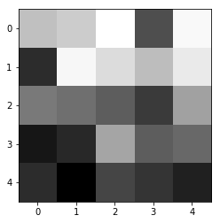

```python
# Get the weights in the first conv layer, "conv1"
# if necessary, change this to reflect the name of your first conv layer
weights1 = net.conv1.weight.data

w = weights1.numpy()

filter_index = 0

print(w[filter_index][0])
print(w[filter_index][0].shape)

# display the filter weights
plt.imshow(w[filter_index][0], cmap='gray')
```

## Feature maps

Each CNN has at least one convolutional layer that is composed of stacked filters (also known as convolutional kernels). As a CNN trains, it learns what weights to include in it's convolutional kernels and when these kernels are applied to some input image, they produce a set of **feature maps**. So, feature maps are just sets of filtered images; they are the images produced by applying a convolutional kernel to an input image. These maps show us the features that the different layers of the neural network learn to extract. For example, you might imagine a convolutional kernel that detects the vertical edges of a face or another one that detects the corners of eyes. You can see what kind of features each of these kernels detects by applying them to an image. One such example is shown below; from the way it brings out the lines in an the image, you might characterize this as an edge detection filter.

[figure not shown]

Next, choose a test image and filter it with one of the convolutional kernels in your trained CNN; look at the filtered output to get an idea what that particular kernel detects.

### TODO: Filter an image to see the effect of a convolutional kernel

[figure not shown]

[figure not shown]

```python
##TODO: load in and display any image from the transformed test dataset

## TODO: Using cv's filter2D function,
## apply a specific set of filter weights (like the one displayed above) to the test image
import cv2

# Loading the image
image = cv2.imread('./images/mona_lisa.jpg')
image = cv2.cvtColor(image, cv2.COLOR_BGR2RGB)
b_image = cv2.cvtColor(image, cv2.COLOR_RGB2GRAY)
plt.imshow(b_image, cmap='gray')
plt.xticks([]), plt.yticks([])
plt.title("Orginal Image - gray scale")


# Applying the image
filtered = cv2.filter2D(b_image, -1, w[filter_index][0])


filter_kernel = np.array([
    [ 0,  -1,  0],
    [-1,  4,  -1],
    [ 0, -1,  0],
])

filtered_image = cv2.filter2D(b_image, -1, filter_kernel)

f, (ax1, ax2, ax3) = plt.subplots(ncols=3, nrows=1, figsize=(10, 5))
ax1.imshow(filter_kernel, cmap='gray')
ax2.imshow(b_image, cmap='gray')
ax3.imshow(filtered_image, cmap='gray')

ax1.set_title('Kernel')
ax2.set_title('Test image')
ax2.set_title('Filtered image')
plt.tight_layout();
# Visualization
```

### Question 4: Choose one filter from your trained CNN and apply it to a test image; what purpose do you think it plays? What kind of feature do you think it detects?

**Answer**: i used high pass filter for the edge detection giving the sharp outline of the edges in the image.

## Moving on!

Now that you've defined and trained your model (and saved the best model), you are ready to move on to the last notebook, which combines a face detector with your saved model to create a facial keypoint detection system that can predict the keypoints on *any* face in an image!